# TS1

Natalie Vernon and Vicky Wheelhouse

## Teaching Statistics 1

#### Session 1a: Introduction to Probability

To get you thinking:

- How would you explain randomness?
- How would you define probability?

[figure not shown]

*Please join with your microphone enabled but muted.*

## What is your experience of teaching statistics content at A level?

- A. I have never taught it
- B. I have taught it for 1 or 2 years
- C. I have taught for more than 2 years in total but not on a regular basis
- D. I have taught it for more than 2 years on a regular basis
- E. Other (tell us in the chat!)

## What strategy would you use?

*A lateral flow test has a specificity (true negative) of 99.97% and a sensitivity (true positive) of 70%. A PCR test has a specificity (true negative) of 100% and a sensitivity (true positive) of 95%.*

*Alix tests positive on a lateral flow test, but then she gets a negative PCR result. It is estimated that 4% of the population have covid. Does Alix have covid?*

## Aims of the session

- To introduce our course tutors and the TS1 course area on Integral
- To discuss and define randomness
- To introduce probability using natural frequencies

## Your aims for your teaching

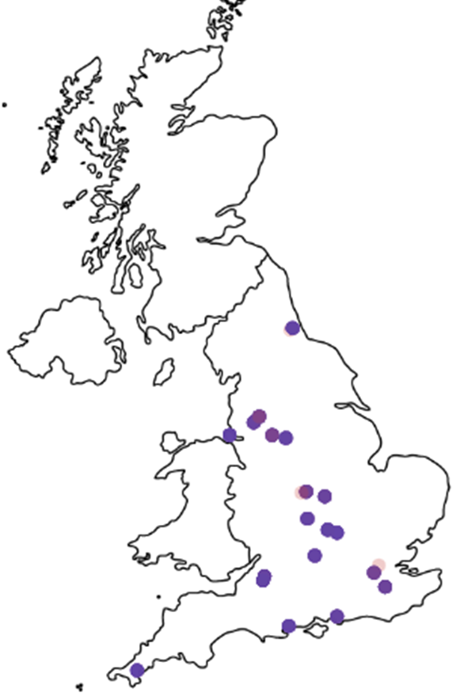

“More about life, less about exam questions”

“More interactivity”

“More questions to deepen understanding, rather that just learning the processes to carry out”

“I would like to be confident in using technology in lessons and for technology to be a ‘normal’ part of A Level lessons.”

## Four dice are rolled 12 times - which is fair?

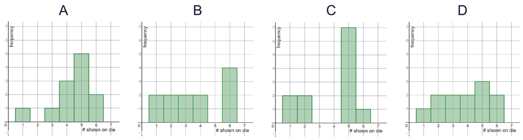

## Resources

- Nrich (possible classroom activity): [What does randomness look like?](https://nrich.maths.org/7250)
- Desmos files: [Random dots](https://www.desmos.com/calculator/p6cvdr00fm), [Rolling a dice](https://www.desmos.com/calculator/4z5gyqsjda), Rolling a dice 6000 times, Relative frequency 100 trials, LFD/PCR frequency tree
- Spotify made its shuffle feature less random so that it would actually feel more random to listeners
- Numberphile: Randomness is random
- BBC More or Less podcasts:
- Law of large numbers
- [What can Education learn from real-world communication of risk & uncertainty?](https://scholarworks.umt.edu/cgi/viewcontent.cgi?article=1329&context=tme) Speigelhalter & Gage
- Nrich: Great expectations: Probability through problems (Speighalter & Gage)
- Article: Why are people testing positive on lateral flow tests then negative on pcr?
- RSS survey tests statistical skills of MPs
- Teaching Probability by Jenny Gage & David Speigelhalter (Cambridge Press)
- David Spiegelhalter’s blog: https://understandinguncertainty.org/
- Winton Centre for Risk & Evidence Communication

AMSP - TS1